# Why low-reliability coverage differs between VH Study 2 and Lai Study 1

Simulation design audit

14 August 2026

# 1 Technical summary

The low-coverage cells in VH Study 2 are **not close analogues of Lai Study 1’s low-ICC cells**, even when their marginal posterior slope reliabilities are similar. The evidence points to a design-induced identification problem, not a coverage-counting error.

- **The marginal reliability target is too close to a correlation-induced floor.** With $|\rho_{u0,u1}|=.5$, the minimum attainable marginal slope reliability rises from .177 at cluster size 3 to .238 at size 25. Targeting .25 therefore leaves almost no reliability to be supplied by direct slope information in the size-25 cell.
- **The calibration creates covariance matrices far outside Lai’s design.** At target reliability .25, VH’s slope/intercept variance ratio ranges from .0011 to .206 and the condition number of the true random-effect covariance reaches about 1,259. Lai fixes that variance ratio at .5, 1, or 2; in the Lai cells nearest reliability .25, the condition number is only 2.0–3.7.
- **The manipulated effect is also much harder in VH.** VH holds the standardized slope effect at .20, .40, or .60, requiring raw paths as large as 20.5 when the calibrated slope SD is tiny. Lai holds the raw path at .40, so its standardized non-null effect is only about .063–.126 in cells near reliability .25.
- **Internal controls argue against a bookkeeping explanation.** VH oracle coverage remains about 94.5% at all reliability levels. Severe failures are concentrated in non-null proxy-score methods, and the refreshed Lai run uses the same VH estimator bundle, common reporting scale, and VH eligibility screen while retaining near-nominal coverage.

The short answer is therefore **yes, the reliability-versus-ICC manipulation matters, but not because posterior reliability is intrinsically a worse design factor**. The current calibration changes only the slope variance while holding the intercept variance large, and at nonzero random-effect correlation it targets a marginal reliability that can mostly come from learning the slope through the intercept. That quantity is poorly aligned with the *unique slope variation* that identifies the slope coefficient in a dual-predictor stage-2 model.

# 2 Evidence base and comparable estimands

## 2.1 Inputs and exact analysis rules

The VH results below reproduce the eligibility path used in `vig_hallquist_2026/analysis/vh_2026_study2.Rmd`: status-10 failures are removed, legacy dual-OLS eligibility is reconstructed for the existing cache, the current method-specific eligibility screen is applied, and the legacy MSEM $|\hat\beta|<5$ threshold is retained. Coverage is then the proportion of eligible intervals satisfying `ci_low <= truth <= ci_high`.

The Lai comparison uses the `latent_sd` rows from the refreshed local Study 1 replication. Those rows use a fixed population latent-slope multiplier for all methods and the same VH-primary eligibility rule. A fixed positive multiplier applied to estimate, SE, interval, and truth cannot change interval inclusion, so this is the cleanest available coverage comparison.

Input completeness and analytical grain

| Input | Grain | Observed rows | Distinct conditions | Check |
| --- | --- | --- | --- | --- |
| VH Study 2 replication cache | replication x condition x method | 5040000 | 720 | Complete expected 5,040,000-row cache |
| Lai Study 1 aggregate summary | condition x method x reporting scale | 3402 | 486 | All 486 Lai conditions present |

The VH cell summaries contain 1,000 retained rows for methods without eligibility failures and fewer for methods with convergence or design exclusions. Lai uses 5,000 generated replications per condition, with method-specific retained counts. All comparisons below are **condition weighted** rather than pooled over retained replications, so a difficult cell does not disappear merely because it converges less often.

## 2.2 The two studies manipulate different objects

In Lai Study 1, the manipulated ICC is the conditional random-intercept ICC,

$$\mathrm{ICC}_{\text{Lai}} =
\frac{\tau_0^2}{\tau_0^2+\sigma^2}\in\{.05,.20,.50\},$$

with $\tau_0^2=\mathrm{ICC}$, $\sigma^2=1-\mathrm{ICC}$, and $\tau_1^2/\tau_0^2\in\{.5,1,2\}$. Thus, changing ICC moves the intercept variance, slope variance, and level-1 residual variance together while keeping the random-effect covariance reasonably balanced.

VH Study 2 instead fixes $\tau_0^2=.81$ and $\sigma^2=1$, so the Lai-style conditional ICC is constant:

$$\mathrm{ICC}_{\text{VH}} = \frac{.81}{.81+1}=.448.$$

It solves only for $\tau_1^2$ to obtain marginal posterior slope reliability $.25$, $.50$, or $.80$. The quantity called `icc` in the preliminary VH report is `slope_variance_marginal / (slope_variance_marginal + outcome_residual_variance)`. That denominator uses the *distal outcome’s* residual variance, not the first-stage level-1 residual variance, and is not comparable to Lai’s ICC. The corresponding heatmap should therefore not be used to conclude that the Lai ICC mechanism has been reproduced.

# 3 Why marginal reliability .25 becomes an extreme cell

## 3.1 The target nearly equals its correlation-induced lower bound

With centered time, iid residuals, and correlated random intercepts and slopes, information about the intercept predicts part of the slope. As $\tau_1^2\rightarrow0$, marginal slope reliability therefore approaches

$$r_{\min}=\rho^2\frac{m\tau_0^2}{\sigma^2+m\tau_0^2}.$$

The project calibration note derives this result and records the same lower bounds. At $m=25$ and $|\rho|=.5$, $r_{\min}=.238$; target .25 is only .012 above that floor.

For a dual-predictor model, however, the coefficient on $u_1$ is identified by the part of $u_1$ not linearly predictable from $u_0$. Its population variance is

$$\operatorname{Var}(u_1\mid u_0)=G_{22}(1-\rho^2).$$

For a balanced centered iid design, a useful diagnostic of direct information about that unique component is

$$r_{\text{unique}}
=\frac{G_{22}(1-\rho^2)}
{G_{22}(1-\rho^2)+\sigma^2/S_{xx}}.$$

This is not a replacement for the full posterior reliability calculation; it is a deliberately targeted signal-to-noise diagnostic for the residualized slope variation used by the stage-2 partial coefficient.

VH target .25 with |rho| = .5: larger clusters move the target closer to the marginal-reliability floor

| Cluster size | Reliability floor | Target minus floor | Slope variance | Slope/intercept variance ratio | Condition number of G | Unique-slope signal ratio |
| --- | --- | --- | --- | --- | --- | --- |
| 3 | 0.177 | 0.073 | 0.05905 | 0.0729 | 19.0 | 8.1% |
| 5 | 0.200 | 0.050 | 0.02064 | 0.02548 | 53.0 | 5.8% |
| 10 | 0.223 | 0.027 | 0.005235 | 0.006463 | 207.0 | 3.4% |
| 25 | 0.238 | 0.012 | 0.000858 | 0.001059 | 1259.4 | 1.5% |

The apparent paradox is now visible: at fixed marginal reliability .25, increasing cluster size makes the calibrated slope variance *smaller*. When the random effects are correlated, the larger cluster also estimates the intercept better, so more of the nominal slope reliability can be inherited through the intercept. By size 25, the unique-slope signal ratio is only about 1.5%, even though the reported marginal slope reliability remains 25%.

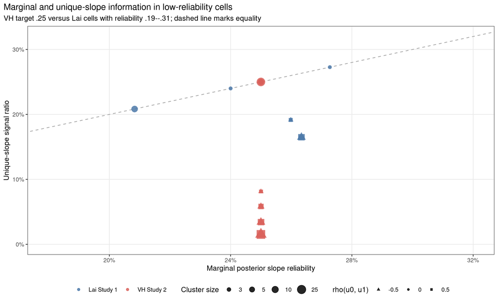

Marginal posterior slope reliability versus direct signal for the slope residualized on the random intercept.

Lai’s nearby cells retain unique-slope signal ratios around 16.5%–27.3%. VH’s correlated cells range from about 1.5% to 8.1%. This is the most direct answer to the ICC-versus-reliability question: Lai’s ICC manipulation does not push the dual-predictor problem into the same near-degenerate conditional geometry.

## 3.2 Effect-size calibration compounds the geometry difference

VH holds the standardized distal-outcome coefficient fixed:

$$\beta_{2,\mathrm{raw}}=
\frac{\beta_{2,\mathrm{std}}}{\sqrt{G_{22}}}.$$

When $G_{22}$ is extremely small, the raw coefficient becomes extremely large. Lai does the opposite: it fixes $\beta_{2,\mathrm{raw}}=.4$, so the standardized effect $\beta_{2,\mathrm{raw}}\sqrt{G_{22}}$ shrinks with the slope variance.

Low-information cells differ on covariance geometry, effect size, and outcome noise

| Quantity | VH Study 2: target reliability .25 | Lai Study 1: reliability .19–.31 |
| --- | --- | --- |
| Manipulated information factor | Marginal posterior slope reliability | Conditional random-intercept ICC |
| Lai-style conditional ICC | 0.448 | .05 or .20 in the nearby cells |
| Slope/intercept variance ratio | 0.0011–0.2058 | 0.50–2.00 |
| Condition number of true G | 4.9–1259.4 | 2.00–3.73 |
| Unique-slope signal ratio | 1.5%–25.0% | 16.5%–27.3% |
| Non-null standardized truth | 0.200–0.600 | 0.063–0.126 |
| Raw slope path | 0.490–20.484 | 0.400–0.400 |
| Distal-outcome residual variance | 0.294–0.902 | 0.952–0.994 |

These are not small differences. Near reliability .25, the Lai non-null truth is at most about .126 on the common latent-SD scale, whereas VH starts at .20 and extends to .60. The largest VH raw path is about 20.5. This remains a valid population model—the oracle confirms that—but it is a severe test of methods that must estimate a tiny latent slope variance and then recover a large raw path or an equivalent standardized product.

# 4 Coverage evidence

## 4.1 Severe undercoverage requires a non-null proxy-score problem

Condition-weighted coverage in low-information cells; Lai’s nearby cells have posterior reliability .19–.31

| Method | Scenario | Mean coverage | Minimum cell | Cells below 70% |
| --- | --- | --- | --- | --- |
| Oracle dual | VH: beta = 0 | 94.5% | 93.2% | 0 |
| Oracle dual | VH: beta = .2 | 94.6% | 92.7% | 0 |
| Oracle dual | VH: beta = .2/.4/.6 | 94.6% | 92.6% | 0 |
| Oracle dual | Lai: beta = 0 | 94.6% | 93.5% | 0 |
| Oracle dual | Lai: raw beta = .4 | 94.6% | 93.7% | 0 |
| Naive dual BLUP | VH: beta = 0 | 94.6% | 91.6% | 0 |
| Naive dual BLUP | VH: beta = .2 | 82.1% | 56.4% | 10 |
| Naive dual BLUP | VH: beta = .2/.4/.6 | 66.6% | 17.9% | 93 |
| Naive dual BLUP | Lai: beta = 0 | 94.3% | 93.4% | 0 |
| Naive dual BLUP | Lai: raw beta = .4 | 93.6% | 92.2% | 0 |
| Fuller | VH: beta = 0 | 99.5% | 97.2% | 0 |
| Fuller | VH: beta = .2 | 87.0% | 40.6% | 5 |
| Fuller | VH: beta = .2/.4/.6 | 75.4% | 0.0% | 50 |
| Fuller | Lai: beta = 0 | 98.7% | 96.6% | 0 |
| Fuller | Lai: raw beta = .4 | 97.4% | 92.0% | 0 |
| Fuller alpha-stepdown | VH: beta = 0 | 91.2% | 62.2% | 6 |
| Fuller alpha-stepdown | VH: beta = .2 | 60.7% | 0.0% | 30 |
| Fuller alpha-stepdown | VH: beta = .2/.4/.6 | 49.2% | 0.0% | 115 |
| Fuller alpha-stepdown | Lai: beta = 0 | 98.3% | 96.6% | 0 |
| Fuller alpha-stepdown | Lai: raw beta = .4 | 96.9% | 92.0% | 0 |
| Lai 2S-PA | VH: beta = 0 | 99.5% | 97.4% | 0 |
| Lai 2S-PA | VH: beta = .2 | 86.9% | 65.4% | 7 |
| Lai 2S-PA | VH: beta = .2/.4/.6 | 73.2% | 19.7% | 79 |
| Lai 2S-PA | Lai: beta = 0 | 98.9% | 96.6% | 0 |
| Lai 2S-PA | Lai: raw beta = .4 | 98.2% | 96.3% | 0 |
| MSEM | VH: beta = 0 | 93.5% | 81.8% | 0 |
| MSEM | VH: beta = .2 | 87.5% | 70.8% | 0 |
| MSEM | VH: beta = .2/.4/.6 | 81.1% | 38.5% | 23 |
| MSEM | Lai: beta = 0 | 95.6% | 87.9% | 0 |
| MSEM | Lai: raw beta = .4 | 95.0% | 86.8% | 0 |

The null-effect rows are the most useful negative control. VH oracle, naive dual BLUP, uncorrected closed-form OLS, and MSEM are near nominal at $\beta=0$; Fuller and 2S-PA are conservative. Coverage then collapses as the non-null standardized effect increases. That pattern is inconsistent with a simple error in the coverage indicator or common reporting scale.

Even VH’s smallest non-null effect, .20, is larger than every non-null Lai truth in the nearby reliability band. Still, effect magnitude is not the whole story: when $\rho=0$, Fuller and 2S-PA are near nominal at VH $\beta=.20$. The largest gap appears when $|\rho|=.5$, exactly where marginal reliability can be supplied through the intercept and the unique-slope signal collapses.

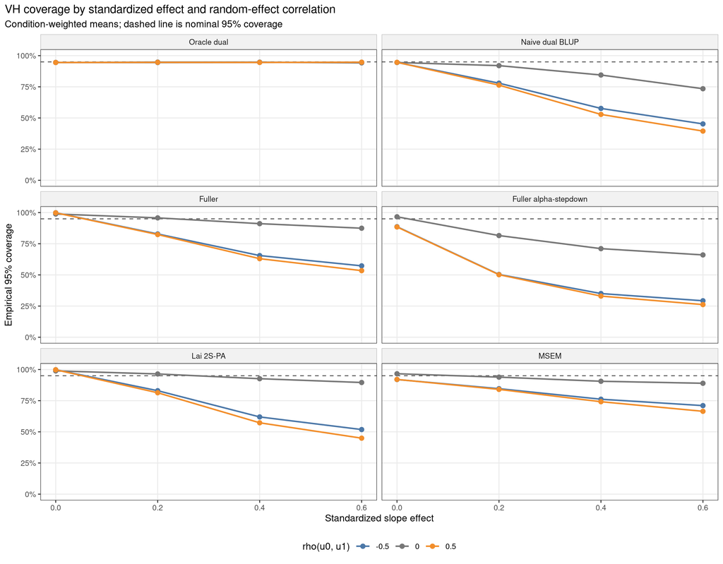

VH Study 2 coverage at target reliability .25, averaged equally over cluster counts and within-cluster sizes.

## 4.2 The failure tracks unique slope information better than the marginal label

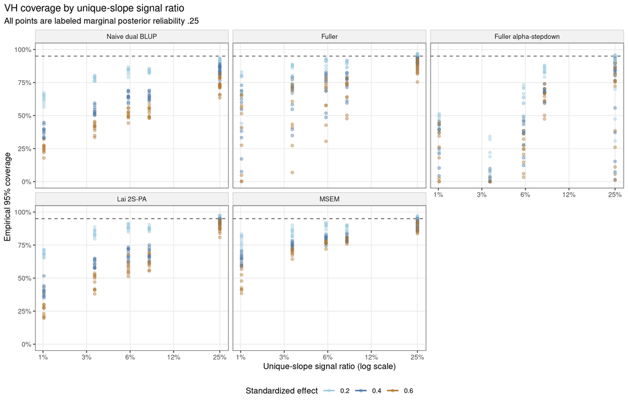

Condition-level VH coverage versus the unique-slope signal ratio at target marginal reliability .25.

This figure should be interpreted descriptively: the unique-signal diagnostic is a deterministic function of cluster size, correlation, and the calibrated variance, not a newly randomized factor. Nevertheless, it exposes why the single label “reliability .25” hides qualitatively different dual-predictor problems.

## 4.3 Bias and standard-error behavior are method specific

VH target reliability .25, non-null effects: condition-weighted interval diagnostics

| Method | Mean coverage | Mean bias | Mean SE / empirical SD | Median SE / empirical SD |
| --- | --- | --- | --- | --- |
| Oracle dual | 94.6% | 0.000 | 0.995 | 0.996 |
| Naive dual BLUP | 66.6% | -0.035 | 0.428 | 0.431 |
| Uncorrected closed-form OLS | 3.1% | -0.353 | 0.994 | 0.996 |
| Fuller | 75.4% | -0.150 | 1.760 | 1.529 |
| Fuller alpha-stepdown | 49.2% | -0.236 | 1.154 | 1.112 |
| Lai 2S-PA | 73.2% | -0.158 | 2.003 | 2.080 |
| MSEM | 81.1% | -0.059 | 1.590 | 1.627 |

The naive BLUP interval is too narrow: its mean reported SE is less than half the empirical SD in the low-reliability cells. That explains much of its undercoverage. Fuller and 2S-PA, by contrast, often have SE ratios above one but still undercover because their intervals are centered on negatively biased estimates in the near-degenerate correlated cells. MSEM is less biased and performs better, but it still deteriorates as the effect grows. The alpha stepdown result is particularly poor here and should be treated as an implementation-specific failure of this variant, not evidence against all Fuller corrections.

# 5 Checks against alternative explanations

## 5.1 Oracle, scaling, and interval coding

Three checks substantially narrow the explanation.

1. **Oracle coverage is stable.** The oracle uses the true random intercept and slope and stays near nominal across reliability, effect, and correlation. The distal-outcome DGM, target truth, stage-2 sample size, and coverage indicator can therefore produce correct coverage in every VH cell.
2. **A common scale cannot change coverage.** Multiplying the estimate, SE, confidence limits, and truth by the same positive population slope SD leaves interval inclusion unchanged. This rules out the raw-versus-common-latent-SD distinction as the cause of the VH/Lai coverage gap.
3. **The refreshed Lai comparison holds code more nearly constant.** The local Lai `latent_sd` view uses the same current estimator helpers and the VH eligibility rule. Published Lai MSEM uses an OpenMx delta-method standardized interval and the historical reporting view has method-specific scaling, so it is not perfectly identical; however, those differences cannot explain why the same VH 2S-PA and MSEM machinery behaves well on the Lai DGM and poorly in the current VH near-floor cells.

## 5.2 Retention rules do not create the main gap

Sensitivity to the VH report’s post-convergence eligibility rule

| Method | Mean converged-only coverage | Mean report-rule coverage | Mean retained fraction |
| --- | --- | --- | --- |
| Uncorrected closed-form OLS | 3.1% | 3.1% | 100.0% |
| Fuller alpha-stepdown | 49.2% | 49.2% | 100.0% |
| Fuller | 75.4% | 75.4% | 100.0% |
| Lai 2S-PA | 73.2% | 73.2% | 100.0% |
| MSEM | 81.1% | 81.1% | 99.9% |
| Naive dual BLUP | 69.7% | 66.6% | 90.0% |
| Oracle dual | 94.6% | 94.6% | 100.0% |

For Fuller, 2S-PA, MSEM, and oracle, the current report rule changes little or nothing among converged low-reliability non-null replications. The naive BLUP screen has a modest effect, but its coverage remains far below nominal under either rule. Differential convergence is still a limitation—especially for 2S-PA—and every coverage statement remains conditional on a usable fit, but it does not explain the broad cross-study contrast.

## 5.3 Source discrepancy: manuscript versus supplement cluster sizes

The local Lai replication follows the archived supplemental code and uses cluster sizes 3, 10, and 25. The manuscript PDF states 3, 5, and 10 in its Study 1 design description. This report compares against the local replication requested for the audit, not a reconstructed manuscript-only grid. The discrepancy should be resolved before calling any figure an exact paper reproduction. It does not account for the present conclusion: VH undercoverage is already visible at overlapping sizes, and the strongest mechanism is the near-floor calibration with a fixed large intercept variance.

# 6 Conclusions

## 6.1 What is established

1. **The low-coverage VH cells are genuinely more difficult than Lai’s low-ICC cells.** Similar marginal posterior reliabilities mask very different covariance condition numbers, unique-slope signal, standardized effects, and distal-outcome residual variances.
2. **The current marginal reliability factor is not orthogonal to cluster size and random-effect correlation.** At $|\rho|=.5$, larger clusters raise the reliability floor, so solving for the same .25 target drives the slope variance toward zero and makes the dual-predictor problem less regular.
3. **The poor coverage is not primarily a CI-counting, common-scale, or oracle problem.** It arises after replacing true random effects with estimated scores or latent variables, and it is strongest for non-null effects.
4. **Methods fail for different immediate reasons.** Naive BLUP SEs are too small; Fuller and 2S-PA suffer large centering bias in the most extreme cells; MSEM is more robust but not immune; the tested alpha-stepdown variant is unreliable in this region.

## 6.2 What is not yet established

The existing factorial outputs cannot apportion the gap into a single causal percentage for covariance geometry, effect magnitude, software, and interval construction because the two studies change all of these jointly. The unique-slope signal diagnostic is strongly explanatory but observational within the existing design. A bridge simulation is needed for a causal decomposition.

# 7 Recommended design and analysis changes

## 7.1 Decisive next step: Study 5 matched-calibration bridge

The most informative next study is not a contest between posterior reliability and ICC as labels. It is a **matched-reliability intervention on the route by which low information is created**. Posterior reliability remains an appealing design quantity because it incorporates the planned time design, cluster size, residual covariance, and the full random-effect covariance. The problem is that one scalar reliability value does not determine that covariance geometry. In the current Study 2 calibration, fixing $G_{00}=.81$ and $sigma^2=1$ and solving only for $G_{22}$ can turn a low-information target into an almost degenerate latent predictor. Lai’s ICC manipulation does not make that same one-coordinate move.

Study 5 therefore holds the data generator, estimators, target reliability, cluster count, and structural estimand fixed while comparing three calibration arms:

1. **Current $G_{22}$ calibration (`current_g22`).** Fix $G_{00}=.81$ and $sigma=1$, and solve $G_{22}$ for marginal posterior slope reliability $.25$. This exactly represents the mechanism under suspicion.
2. **Shape-preserving marginal calibration (`shape_preserving_marginal`).** Fix a regular covariance shape with $G_{22}/G_{00}=1$, retain the requested intercept–slope correlation, and solve $sigma$ for the same marginal posterior slope reliability $.25$. This retains posterior reliability as the manipulated factor but prevents reliability from being achieved by collapsing one latent variance.
3. **Shape-preserving partial calibration (`shape_preserving_partial`).** Use the same regular $G$ shape, but solve $sigma$ for posterior reliability of the latent slope residualized on the random intercept. This tests whether the remaining problem is the *definition* of reliability rather than the route used to attain it.

For the third arm, define

$$\eta_i=u_{1i}-\frac{G_{12}}{G_{11}}u_{0i},\qquad
\mathbf c=\left(-\frac{G_{12}}{G_{11}},1\right)^\mathsf T,$$

and calibrate the exact posterior reliability

$$R_\eta
=1-\frac{E\left(\mathbf c^\mathsf T
V_{i,\mathrm{post}}\mathbf c\right)}
{\mathbf c^\mathsf T G\mathbf c},\qquad
V_{i,\mathrm{post}}=\left(G^{-1}+Z_i^\mathsf T
R_i^{-1}Z_i\right)^{-1}.$$

This contrast is not merely a convenient signal ratio. Reparameterizing the stage-2 predictors from $(u_0,u_1)$ to $(u_0,\eta)$ leaves the coefficient on the focal slope unchanged. $R_\eta$ therefore measures posterior information for the latent predictor variation that identifies the partial slope coefficient, while still using the full posterior covariance. It also remains well defined for unbalanced clusters and non-iid $R_i$, unlike the simple balanced-design approximation based only on $S_{xx}$.

The compact confirmatory grid fixes $J=100$ clusters and crosses:

- calibration arm: the three arms above;
- cluster size: $m=10,25$;
- marginal intercept–slope correlation: $\rho=0,.5$; and
- standardized focal slope effect: $0,.2,.4$.

This yields 36 conditions. Each condition should receive 1,000 replications. The full seven-method Study 2 implementation is reused unchanged: oracle dual, naive dual BLUP, uncorrected closed-form OLS, Fuller, Fuller alpha-stepdown, Lai 2S-PA, and MSEM. The confirmatory comparison emphasizes oracle, naive dual BLUP, Fuller, Lai 2S-PA, and MSEM; the two additional corrected-score variants help localize any failure without introducing a new estimator during the DGM experiment. Fixed standardized effects keep the focal coefficient and its unique variance contribution comparable across arms; the raw coefficient is allowed to change with the latent slope scale, as it must under a standardized estimand.

Every condition manifest records both reliability definitions whether or not they were targeted, along with $sigma$, $G_{22}/G_{00}$, $kappa(G)$, $G_{22}-G_{12}^2/G_{11}$, and a Lai-style conditional slope ICC. These are essential manipulation checks. In particular, matching the targeted scalar is not enough if the supposedly shape-preserving arms accidentally reproduce the same near-singular geometry.

### 7.1.1 Prespecified interpretation

The three contrasts resolve different branches of the dilemma:

- If `shape_preserving_marginal` restores coverage while `current_g22` fails, posterior reliability is defensible; the culprit is the one-coordinate calibration that collapses $G_{22}$.
- If both marginal-reliability arms fail but `shape_preserving_partial` restores coverage, marginal slope reliability is misaligned with the dual-predictor estimand and $R_\eta$ should become the primary information factor.
- If the two shape-preserving arms perform similarly and both restore coverage, covariance regularity matters more than which of the two posterior reliability definitions is targeted. The simpler marginal definition can be retained, provided covariance-shape guards are imposed.
- If all proxy methods fail only for non-null or larger effects while oracle coverage remains nominal, the remaining limitation is estimator/interval behavior under measurement error, not the DGM calibration alone.
- If oracle coverage also fails, the comparison does not adjudicate the reliability question; simulation truth, standardization, and interval construction must be audited first.

Coverage should be interpreted with its Monte Carlo uncertainty. With 1,000 eligible replications, the approximate 95% binomial fluctuation band around nominal .95 coverage is about .936–.964. The primary evidence is the within-cell change across arms, accompanied by bias, empirical SD, mean model SE, convergence, and the SE-to-empirical-SD ratio. Averaging across effect sizes would conceal the null/non-null pattern already visible in Study 2.

The executable Study 5 implementation accompanies this report in `vig_hallquist_2026/vh_study5.R`, with its design in `vig_hallquist_2026/vh_designs.R` and a results template in `vig_hallquist_2026/analysis/vh_2026_study5.Rmd`.

## 7.2 Redefine the low-information factor for a dual-predictor estimand

For a model in which both random intercept and random slope predict the distal outcome, the primary information factor should track the slope variation that remains after adjusting for the intercept. One option for balanced iid cells is to calibrate

$$r_{\text{unique,target}}
=\frac{G_{22}(1-\rho^2)S_{xx}}
{\sigma^2+G_{22}(1-\rho^2)S_{xx}},$$

and treat the existing full marginal posterior slope reliability as a reported derived quantity. A more general implementation could define reliability for the residualized latent contrast directly from the full posterior covariance. This would align the manipulated information factor with the partial slope coefficient actually being evaluated.

If marginal posterior reliability remains the primary factor, impose a design guard such as a minimum distance above the correlation-induced floor and a maximum covariance condition number. The current $.25$ target at $m=25$, $|\rho|=.5$ should be labeled a **near-boundary stress test**, not treated as exchangeable with the $\rho=0$ reliability-.25 cell.

## 7.3 Run a small bridge factorial before changing the main simulation

Study 5 operationalizes the bridge above in a deliberately small first pass. It uses two cluster sizes and fixed standardized effects so that the key calibration-arm contrast can be estimated with adequate Monte Carlo precision before expanding the grid. A second-stage extension should add $m=3$, $\rho=-.5$, alternative regular ratios $G_{22}/G_{00}\in\{.5,2\}$, and a fixed raw-path arm only if the initial three-arm comparison leaves the mechanism ambiguous. Those additions are informative, but including them initially would spend simulation effort on effect-scale and symmetry questions before testing the central covariance-geometry hypothesis.

## 7.4 Keep the current cells, but change their interpretation

The current results are scientifically useful as a robustness study. They show that marginal slope reliability can be misleading for dual-predictor inference when intercept-slope correlation carries most of the marginal information. Recommended reporting changes are:

- replace the preliminary `icc` heatmap with the actual Lai-style conditional ICC and label it constant at .448 in VH Study 2;
- add the reliability floor, target-minus-floor, slope/intercept variance ratio, covariance condition number, and unique-slope signal diagnostic to the condition manifest and figures;
- stratify low-reliability coverage by null versus non-null effect and by $\rho$, rather than averaging those cells together;
- retain oracle coverage and SE/empirical-SD ratios beside method coverage;
- present near-floor cells as a separate stress-test panel; and
- investigate penalized variance estimation or bootstrap/profile intervals only after the DGM comparison is made explicit, because wider intervals alone will not repair large centering bias.

# 8 Limitations and reproducibility

- VH coverage is based on the existing `vig_hallquist_slurm` cache referenced by the current Study 2 R Markdown file. Newer or partial output directories were not substituted silently.
- Lai comparisons use condition-level aggregates, while VH calculations start from replication-level output. Both use condition-weighted summaries and the VH-primary eligibility rule, but some replication-level Lai sensitivity checks would require rereading the per-condition compressed files.
- The simple unique-slope signal ratio used in the retrospective diagnosis is a balanced-iid approximation. Study 5 instead implements $R_\eta$ from the full posterior covariance, which extends directly to arbitrary planned $Z_i$ and positive-definite $R_i$. Whether it is the most useful primary design factor remains an empirical question for the bridge simulation.
- Coverage is conditional on convergence and eligibility. Joint metrics that count nonconvergence as failure answer a different question and should be reported separately, not substituted for inferential coverage.

The report can be rendered from the repository root with:

```r
rmarkdown::render(
  "reports/vh_study2_lai_coverage_investigation.Rmd",
  output_file = "vh_study2_lai_coverage_investigation.html"
)
```

Primary local sources:

- `vig_hallquist_2026/analysis/vh_2026_study2.Rmd`
- `vig_hallquist_2026/analysis/vh_2026_study5.Rmd`
- `vig_hallquist_2026/vh_designs.R`
- `vig_hallquist_2026/vh_study5.R`
- `R/reliability_calibration.R`
- `lai_study1_replication_vh/designs.R`
- `lai_study1_replication_vh/estimators.R`
- `lai_study1_replication_vh/README.md`
- `documentation/posterior_reliability_to_random_effects.md`
- `documentation/Lai2026_2SPA.pdf`, especially the Study 1 design/results discussion and Figure 3